# Project_Applied_Statistics_Puneet

**Q1.Import the necessary libraries**

```python
#Q1.  import the necessary libraries
import numpy as np
import pandas as pd
import matplotlib.pyplot as plt
%matplotlib inline
import seaborn as sns
import scipy.stats as stats
from sklearn.preprocessing import LabelEncoder
import copy
from scipy.stats import ttest_ind
from statsmodels.stats.proportion import proportions_ztest
```

**Q2. import data as dataframe**

```python
#Q2. import data as dataframe
ins_data = pd.read_csv("insurance.csv")
ins_data.head()
```

|  | age | sex | bmi | children | smoker | region | charges |
| --- | --- | --- | --- | --- | --- | --- | --- |
| 0 | 19 | female | 27.900 | 0 | yes | southwest | 16884.92400 |
| 1 | 18 | male | 33.770 | 1 | no | southeast | 1725.55230 |
| 2 | 28 | male | 33.000 | 3 | no | southeast | 4449.46200 |
| 3 | 33 | male | 22.705 | 0 | no | northwest | 21984.47061 |
| 4 | 32 | male | 28.880 | 0 | no | northwest | 3866.85520 |

**Q3.a. shape of the data gives us the rows and columns**

```python
#Q3.a. shape of the data gives us the rows and columns
ins_data.shape
```

```
(1338, 7)
```

**Q3.b. Data type of each attribute**

```python
#Q3.b. gives the datatype of each attribute (can also be found out using the method in the next cell)
print(ins_data.dtypes)
# or
# Also gives the datatype of each attribute
ins_data.info()
```

```
age           int64
sex          object
bmi         float64
children      int64
smoker       object
region       object
charges     float64
dtype: object
<class 'pandas.core.frame.DataFrame'>
RangeIndex: 1338 entries, 0 to 1337
Data columns (total 7 columns):
 #   Column    Non-Null Count  Dtype
---  ------    --------------  -----
 0   age       1338 non-null   int64
 1   sex       1338 non-null   object
 2   bmi       1338 non-null   float64
 3   children  1338 non-null   int64
 4   smoker    1338 non-null   object
 5   region    1338 non-null   object
 6   charges   1338 non-null   float64
dtypes: float64(2), int64(2), object(3)
memory usage: 73.3+ KB
```

**Q3.c Checking the presence of missing values**

```python
#Q3.c. Looking for missing values - the total rows matches with the rows with non null values
# Also gives the datatype of each attribute
ins_data.info()
# or
# alternatively we can find the sum of null values for each column
ins_data.isnull().sum()
```

```
<class 'pandas.core.frame.DataFrame'>
RangeIndex: 1338 entries, 0 to 1337
Data columns (total 7 columns):
 #   Column    Non-Null Count  Dtype
---  ------    --------------  -----
 0   age       1338 non-null   int64
 1   sex       1338 non-null   object
 2   bmi       1338 non-null   float64
 3   children  1338 non-null   int64
 4   smoker    1338 non-null   object
 5   region    1338 non-null   object
 6   charges   1338 non-null   float64
dtypes: float64(2), int64(2), object(3)
memory usage: 73.3+ KB
```

```
age         0
sex         0
bmi         0
children    0
smoker      0
region      0
charges     0
dtype: int64
```

Age, and children are integer values while the bmi and charges can contain decimals and hence float sex, smoker and region are classification or string values and hence treated as the object datatype. The datatypes have no null data as indicated in the code comments above

**Q3.d. 5 point summary of numerical attributes**

```python
#Q3.d. point summary of the data viz. 1st Quartile(25%), median(50%),3rd Quartile(75%) , min and max of data
ins_data.describe(include='all')
```

|  | age | sex | bmi | children | smoker | region | charges |
| --- | --- | --- | --- | --- | --- | --- | --- |
| count | 1338.000000 | 1338 | 1338.000000 | 1338.000000 | 1338 | 1338 | 1338.000000 |
| unique | NaN | 2 | NaN | NaN | 2 | 4 | NaN |
| top | NaN | male | NaN | NaN | no | southeast | NaN |
| freq | NaN | 676 | NaN | NaN | 1064 | 364 | NaN |
| mean | 39.207025 | NaN | 30.663397 | 1.094918 | NaN | NaN | 13270.422265 |
| std | 14.049960 | NaN | 6.098187 | 1.205493 | NaN | NaN | 12110.011237 |
| min | 18.000000 | NaN | 15.960000 | 0.000000 | NaN | NaN | 1121.873900 |
| 25% | 27.000000 | NaN | 26.296250 | 0.000000 | NaN | NaN | 4740.287150 |
| 50% | 39.000000 | NaN | 30.400000 | 1.000000 | NaN | NaN | 9382.033000 |
| 75% | 51.000000 | NaN | 34.693750 | 2.000000 | NaN | NaN | 16639.912515 |
| max | 64.000000 | NaN | 53.130000 | 5.000000 | NaN | NaN | 63770.428010 |

The value for age is recorded from 18 to 64, and 75% people have 2 children or less which one expects to be represented in a normal population. A healthy bmi ranges from 18.5 – 24.9, looking at the 50% and 75% values it appears that the population is not so healthy and is tilting towards the fat end.

**Q3.e Distribution of ‘bmi’, ‘age’ and ‘charges’ columns.**

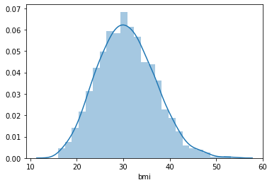

```python
# Q3.e
# distribution of bmi
sns.distplot(ins_data.bmi,kde="False");
```

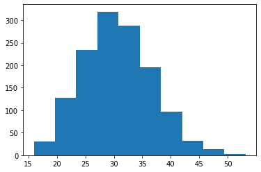

```python
plt.hist(ins_data.bmi);
```

The bmi is distributed normally. The mean and the median almost coincide. The graph shows the probability or frequency distribution of the different values as shown above.

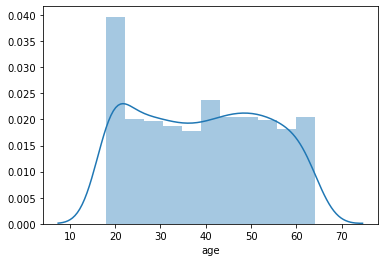

```python
# Q3.e
# distribution of age
sns.distplot(ins_data.age,kde="False");
# ins_data.age.value_counts()
# ins_data['age'].value_counts().plot(kind='bar')
```

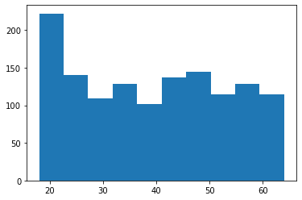

```python
plt.hist(ins_data.age);
```

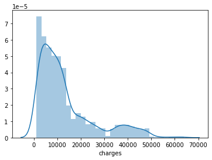

```python
# Q3.e /f
# distribution of charges
sns.distplot(ins_data.charges,kde="False");
```

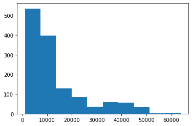

```python
plt.hist(ins_data.charges);
```

**Q3.f. Measure of skewness of ‘bmi’, ‘age’ and ‘charges’ columns**

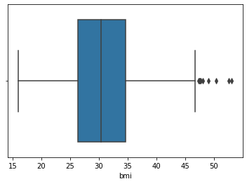

```python
# Q3.f. Measure of skewness of bmi
sns.boxplot("bmi",data=ins_data);
```

The data is normally distributed. There are a few outliers though as shown in the boxplot above.

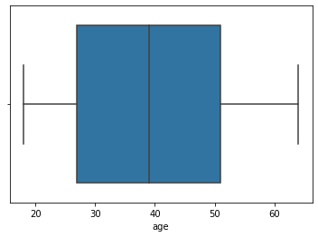

```python
# Q3.f. Measure of skewness of age
sns.boxplot("age",data=ins_data);
```

The Age is distributed uniformly as shown in the box plot above.Visually the plot doesn't seem to be skewed.

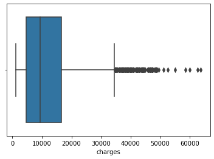

```python
# Q3.f. Measure of skewness of charges
sns.boxplot("charges",data=ins_data);
```

The box plot looks quite skewed, this is also indicated by the histogram plots. There seems to be a lot of outliers present too as can be seen above

```python
# Q3.f. Calculating the measure of skewness
print('bmi skew value',stats.skew(ins_data.bmi))
print('age skew value',stats.skew(ins_data.age))
print('charges skew value',stats.skew(ins_data.charges))
```

```
bmi skew value 0.28372857291709386
age skew value 0.055610083072599126
charges skew value 1.5141797118745743
```

The conclusions drawn by the boxplot and the distribution plots are also verifiable by calculating the skew value of each column. The skew for bmi is low, the age has almost 0 skew value and the charges as expected are highly skewed.

**Q3.g. Checking the presence of outliers in ‘bmi’, ‘age’ and ‘charges columns**  
Referring to the box plots above , we can clearly see that charges have a lot of outliers , bmi has a few and age has almost no outliers.  
We can calculate the exact number of outliers as given below

```python
# Q3.g outliers for bmi
first_quartile = np.percentile(ins_data['bmi'], 25)
third_quartile = np.percentile(ins_data['bmi'], 75)
iqr = third_quartile - first_quartile
print(iqr)
low_lim = first_quartile - 1.5 * iqr
up_lim =  third_quartile + 1.5 * iqr
print(low_lim,up_lim)
outlier =[]
for x in ins_data['bmi']:
    if ((x> up_lim) or (x<low_lim)):
         outlier.append(x)
# print(' outlier in the dataset is', outlier)
print(' no. of outliers are', len(outlier))
```

```
8.3975
13.7 47.290000000000006
 no. of outliers are 9
```

The bmi has very few outliers, as indicated by the count above.This is also verifiable in the boxplot. This indicates that considering the distribution there are only 9 people who are beyond the cut off value.

```python
# Q3.g outliers for age
first_quartile = np.percentile(ins_data['age'], 25)
third_quartile = np.percentile(ins_data['age'], 75)
iqr = third_quartile - first_quartile
print(iqr)
low_lim = first_quartile - 1.5 * iqr
up_lim =  third_quartile + 1.5 * iqr
print(low_lim,up_lim)
outlier =[]
for x in ins_data['age']:
    if ((x> up_lim) or (x<low_lim)):
         outlier.append(x)
# print(' outlier in the dataset is', outlier)
print(' no. of outliers are', len(outlier))
```

```
24.0
-9.0 87.0
 no. of outliers are 0
```

There are 0 outliers and the same is verifiable in the boxplot above

```python
# Q3.g outliers for charges
first_quartile = np.percentile(ins_data['charges'], 25)
third_quartile = np.percentile(ins_data['charges'], 75)
iqr = third_quartile - first_quartile
print(iqr)
low_lim = first_quartile - 1.5 * iqr
up_lim =  third_quartile + 1.5 * iqr
print(low_lim,up_lim)
outlier =[]
for x in ins_data['charges']:
    if ((x> up_lim) or (x<low_lim)):
         outlier.append(x)
# print(' outlier in the dataset is', outlier)
print(' no. of outliers are', len(outlier))
```

```
11899.625365
-13109.1508975 34489.350562499996
 no. of outliers are 139
```

There are quite a number of outliers for charges as represented by the box plot. The exact value is printed above. This is also an indicator of skewness and is represented in all the distributions plotted in the above sections.

**Q3.h Distribution of categorical columns (include children)**  
We can plot univariate, bivariate and multicategorical plots for categorical columns.  
The univariate plots include  
1) countplot  
The bivariate plots include the following  
1)boxplot  
2)swarmplot  
3)stripplot  
The multi categorical plot would include  
4)catplot  
Since its the dataset for insurance it would be interesting to derive relationship between charges and rest of the columns to understand the effect of each of the parameters on charges for bivariate data analysis

```python
# Q3.h Univariate analysis of categorical data
ins_data.head()
```

|  | age | sex | bmi | children | smoker | region | charges |
| --- | --- | --- | --- | --- | --- | --- | --- |
| 0 | 19 | female | 27.900 | 0 | yes | southwest | 16884.92400 |
| 1 | 18 | male | 33.770 | 1 | no | southeast | 1725.55230 |
| 2 | 28 | male | 33.000 | 3 | no | southeast | 4449.46200 |
| 3 | 33 | male | 22.705 | 0 | no | northwest | 21984.47061 |
| 4 | 32 | male | 28.880 | 0 | no | northwest | 3866.85520 |

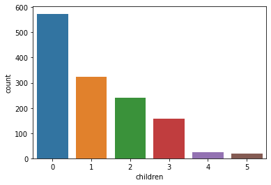

```python
#Q3.h countplot of children
sns.countplot(ins_data.children);
```

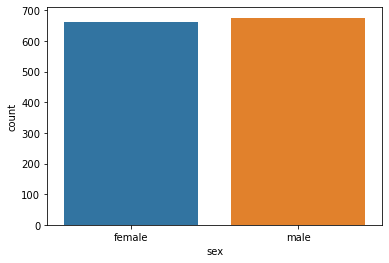

```python
#Q3.h countplot of sex
sns.countplot(ins_data.sex);
```

```python
#Q3.h countplot of sex
ins_data.sex.value_counts()
```

```
male      676
female    662
Name: sex, dtype: int64
```

There are slightly more males than females in the data.

```
no     1064
yes     274
Name: smoker, dtype: int64
```

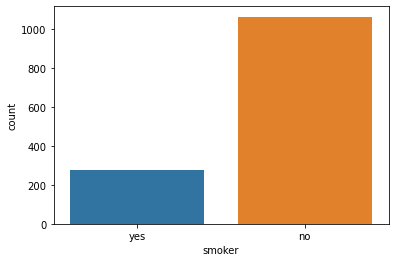

```python
#Q3.h countplot of smokers
print(ins_data.smoker.value_counts())
sns.countplot(ins_data.smoker);
```

There are very few smokers as compared to non smokers in the dataset

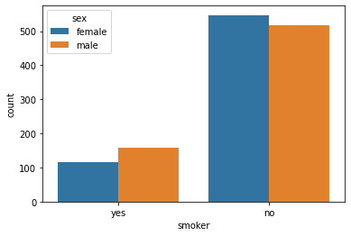

```python
#Q3.h countplot of smokers v/s sex
sns.countplot(ins_data.smoker, hue = ins_data.sex);
```

There are more male smokers than the female smokers

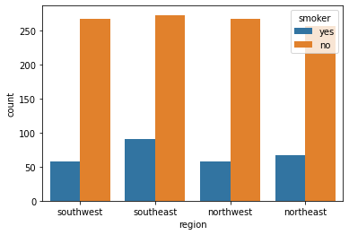

```python
# #Q3.h countplot of  smoker/region
sns.countplot(ins_data.region, hue = ins_data.smoker);
```

There are more smokers in the south east zone as compared to the rest of the regions

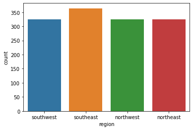

```python
#Q3.h countplot of region
sns.countplot(ins_data.region);
```

The distribution of data is pretty much homogenous except for south east which is slightly more.